# Machine Learning in Python

This notebook is primarily for learning the fundamentals and basics of Machine learning in Python.

I used [W3Schools](https://www.w3schools.com) to help me in this, alongside the SciKit Learn Documentation.

## Mean, Median, Mode

When looking at a dataset, what can we learn? Primarily, in data science, there are 3 values that interest us:

- Mean - The Arithmetic average value
- Median - The mid-point value ($Q_2$)
- Mode - The most common value

```python
import numpy as np
from scipy import stats
import matplotlib.pyplot as plt

data = np.random.randint(0,100, size=50)
print(data)
```

```
[95 97 75 95  2 18 80 96 57 84 51 69 60 74 26 43 74 60 28 76 36  9 65  2
 52 38 73 45 48 44  4 79 88 49 27 48 30 21 54 62 95 82 36 63 99 71 26 36
 99 29]
```

Looking at the data above, we can use some tools from numpy and scipy to calculate some values.

```python
# Finding Mean
np.mean(data)
```

```
55.4
```

```python
# Finding Median
np.median(data)
```

```
55.5
```

```python
# Finding Mode
stats.mode(data)
```

```
ModeResult(mode=36, count=3)
```

## Standard Deviation

Standard Deviation describes how spread out the values are.

- A low standard deviation means that most of the values are close to the mean.
- A high standard deviation means that the values are spread out over a wider range from the mean.

Using the same randomly generated set, we can calculate the standard deviation

```python
# Finding Standard Deviation
np.std(data).round(2)
```

```
27.51
```

### Variance

Variance is another number that indicated how spread out the values are.

In fact, taking the square of the standard deviation yields the variance.

Variance is given by: $$ \text{Var}(X) = E[X^2]-E[X]^2 $$

```python
# Finding Variance
np.var(data).round(1)
```

```
756.6
```

Variance is often represented by $\sigma$ and variance is often represented as $\sigma^2$

## Percentiles

Percentiles are used in statistics to give you a number that describes the value that a given percent of the values are lower than.

Normally, the percentiles used are $25$%, $50$% and $75$%, labelled $Q_1$, $Q_2$ and $Q_3$ respectively.

To calculate the 75. percentile of the earlier generated data set:

```python
# Finding 75. Percentile
np.percentile(data, 75)
```

```
75.75
```

## Data Distribution

In the real world, data sets are much bigger than just 50 data values.

We'll use numpy to generate this big data set.

```python
# Generating big data
data = np.random.uniform(0, 10, 2500)
print(data)
```

```
[1.32271913 1.94347999 7.73150273 ... 4.45455029 4.22749302 1.84841667]
```

### Histogram

We can then create a histogram, which uses frequency density and class width to visualise data.

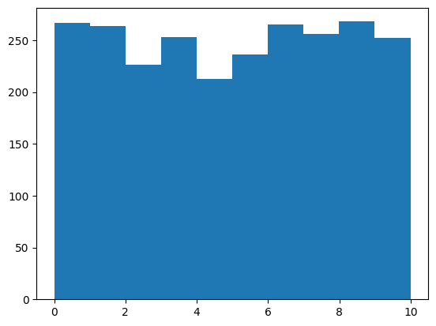

```python
# Visualising Data using a histogram
plt.hist(data, 10)
plt.show()
```

An array containing 2500 is not considered particularly large, but now we can create larger data sets, more akin to real-life data.

```
[0.99978161 0.83900966 1.73746567 ... 2.41468804 1.39373815 3.81666137]
```

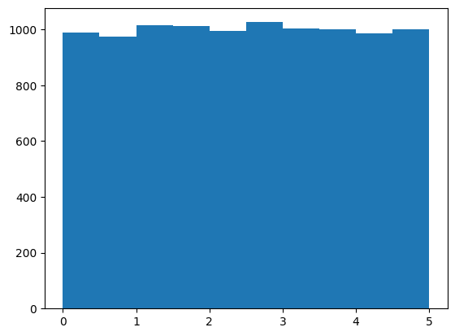

```python
# Generating and visualising Big Data
data = np.random.uniform(0,5,10000)
print(data)

plt.hist(data, 10)
plt.show()
```

## Normal Distribution

The normal, or Gaussian data distribution is a kind of data distribution where the values are concentrated around a given value.

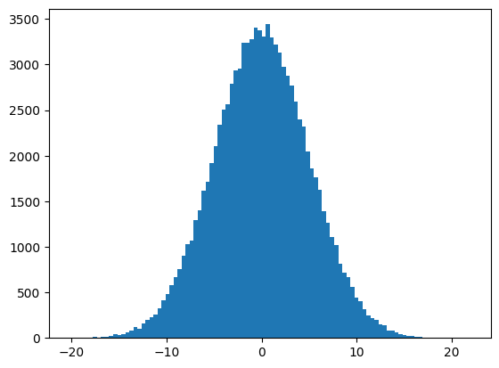

```python
# Normal data and visualisation
data = np.random.normal(0,5,100000)

plt.hist(data, 100)
plt.show()
```

This is why normal/Gaussian distributions are also known as the bell curve.

## Scatter Plot

A scatter plot is a diagram where each value in the data set is represented by a dot.

We need 2 lists for both x and y values here.

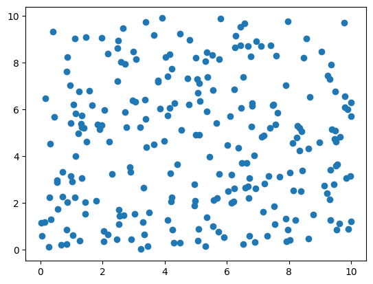

```python
# Scatter Plotting
x = np.random.uniform(0,10,250)
y = np.random.uniform(0,10,250)

plt.scatter(x,y)
plt.show()
```

In machine learning, the data sets can contain thousands - even millions of values.

You might not have real world data when you are testing an algorithm, you might have to use randomly generated values, as we used above.

## Linear Regression

Regression is the term used when you try to find the relationship between variables.

We use the regression to predict the outcome of future events.

Linear Regression uses the relationship between the data-points to draw a straight line through all of them.

We can then use this line to predict future values.

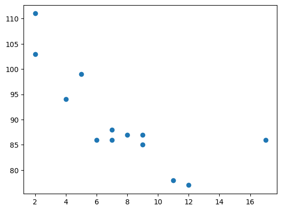

```python
# Linear Regression Scatter Plotting
x = [5,7,8,7,2,17,2,9,4,11,12,9,6]
y = [99,86,87,88,111,86,103,87,94,78,77,85,86]

plt.scatter(x,y)
plt.show()
```

We can use scipy to gather statistical values about the data.

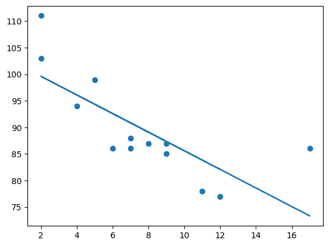

```python
# Linear Regression Modelling
slope, intercept, r, p, std_err = stats.linregress(x,y)

def f(x):
    return slope * x + intercept

model = list(map(f, x))

plt.scatter(x,y)
plt.plot(x, model)
plt.show()
```

It is important to know how the relationship between the values of the x-axis and y-axis is.

The relationship - coefficient of correlation - is called $r$, which ranges from $-1$ to $1$, where $|r|=0$ which means no relationship, and $|r|=1$ means 100% related.

The python and scipy module computes this value for you.

Predicting future values can be done by using the function we've found earlier.

```python
# Finding value at x=10, which is not given
print(f(10).round(1))
```

```
85.6
```

However, there are some situations where a linear regression doesn't fit.

```
-0.06682604293885168
```

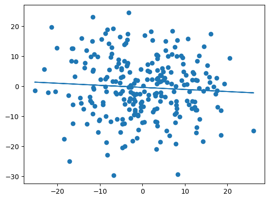

```python
# Non-linear example
x = np.random.normal(0,10,250)
y = np.random.normal(0,10,250)

slope, intercept, r, p, std_err = stats.linregress(x,y)

def f(x):
    return slope * x + intercept

model = list(map(f, x))

plt.scatter(x, y)
plt.plot(x, model)

print(r)
plt.show()
```

## Polynomial Regression

Polynomial regression is used when linear regression is not useable for the data set.

The polynomial regression uses polynomials to draw a polynomial line through data points.

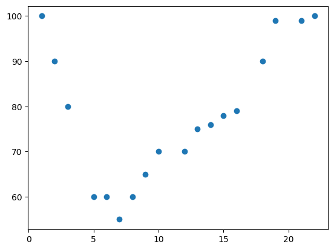

```python
# Polynomial Plot
x = [1,2,3,5,6,7,8,9,10,12,13,14,15,16,18,19,21,22]
y = [100,90,80,60,60,55,60,65,70,70,75,76,78,79,90,99,99,100]

plt.scatter(x, y)
plt.show()
```

Then, by specifying the degree of the polynomial, we can use numpy to create a polynomial fit

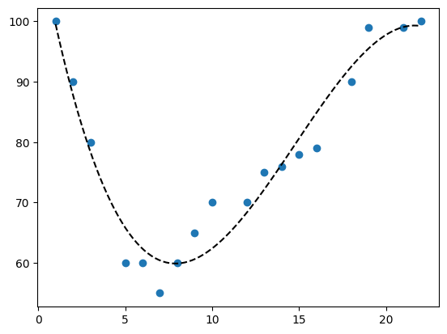

```python
# Polynomial Modelling
model = np.poly1d(np.polyfit(x, y, 3))

line = np.linspace(1,22,100)

plt.scatter(x, y)
plt.plot(line, model(line), color = "black", linestyle = "--")
plt.show()
```

The relationship is measured with a value called the r-squared value.

The r-squared value ranges from 0 to 1, where 0 means no relationship and 1 means 100% related.

Python, and sklearn compute this value for you.

```python
# Finding r2
from sklearn.metrics import r2_score

print(round(r2_score(y, model(x)), 2))
```

```
0.94
```

We can predict future values by use the model array from above.

```python
# Predicting value at x-value not given
model(17).round(1)
```

```
88.9
```

There are some situations where polynomial regression does not work

```
0.1
```

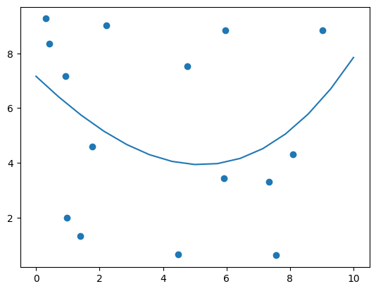

```python
# Non-Polynomial regression
x = np.random.uniform(0,10,15)
y = np.random.uniform(0,10,15)

model = np.poly1d(np.polyfit(x, y, 3))

line = np.linspace(0, 10, 15)

plt.scatter(x, y)
plt.plot(line, model(line))

print(round(r2_score(y, model(x)), 2))
plt.show()
```

## Multiple Regression

Multiple regression is like linear regression, but with more than one independent value, meaning that we try to predict a value based on 2 or more variables.

We use pandas in python to analyse data sets like this.

```python
# Multivariate Data Analysis
import pandas
from sklearn import linear_model

df = pandas.read_csv("datavol.csv")

x = df[["Weight", "Volume"]]
y = df["CO2"]

regr = linear_model.LinearRegression()
regr.fit(x.values,y)

predictedCO2 = regr.predict([[2300,1300]])

print(predictedCO2)
```

```
[107.2087328]
```

So, we've predicted that a car with a 1.3 liter engine and a weight of 2300 kg will release approximately 107 grams of $CO_2$ for each kilometer it drives.

### Coefficient

The coefficient is a factor that describes the relationship with an unknown variable.

In this case, we can ask for the coefficient value of weight against $CO_2$ and for volume against $CO_2$.

```python
print(regr.coef_)
```

```
[0.00755095 0.00780526]
```

This tells us that if the weight increases by 1kg, $CO_2$ increases by 0.00755g, and if the engine size increases by $1\text{cm}^3$, $CO_2$ emissions increase by 0.00781g.

## Scale

When data has different values, or even different measurement units, we can scale data into new, more comparable values to analyse the data.

Here, we will use standardisation to scale data into comparable values - This is the formula: $$ z = \dfrac{x-u}{s} $$ Where $z$ is the new value, $x$ is the original value, $u$ is the mean and $s$ is the standard deviation.

Now, we can use Python sklearn module called `StandardScaler()`, which returns a scaler object with methods for transforming data sets.

```python
# Scaling Values
from sklearn.preprocessing import StandardScaler
from sklearn import linear_model
scale = StandardScaler()

df = pandas.read_csv("datacm.csv")

X = df[["Weight", "Volume"]]
y = df["CO2"]

scaledX = scale.fit_transform(X.values)
```

We can use the scale here to predict $CO_2$ emission.

```python
# Predicting CO2
regr = linear_model.LinearRegression()
regr.fit(scaledX, y)

scaled = scale.transform([[2300, 1.3]])

predictedCO2 = regr.predict([scaled[0]])
print(predictedCO2)
```

```
[107.2087328]
```

## Train/Test

In machine learning, we create models to predict the outcome of certain events, and to test whether the model is good enough, we use a method called Train/Test.

It's called Train/Test because we split data into 2 sets, a training set and a testing set - 80:20 Training to Test.

We use the training set to create the model, and use the testing set to test the accuracy of the model.

We start with a data set to test, in this case we use a set illustrating 100 customers in a shop and their shopping habits - how many minutes they spend to how much money they spend.

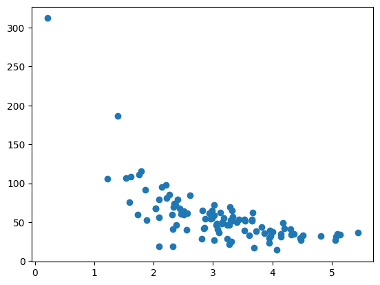

```python
# Creating data
x = np.random.normal(3,1,100)
y = np.random.normal(150,40,100)/x

plt.scatter(x, y)
plt.show()
```

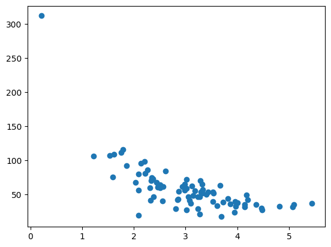

```python
# Creating training and test data
# Showing training data
train_x = x[:80]
train_y = y[:80]

test_x = x[80:]
test_y = y[80:]

plt.scatter(train_x, train_y)
plt.show()
```

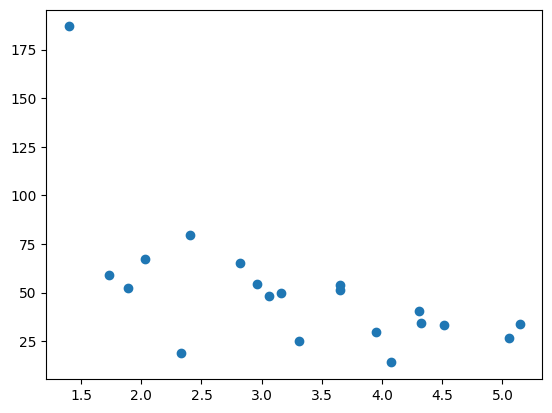

```python
# Showing test data
plt.scatter(test_x, test_y)
plt.show()
```

Now, this data looks like a polynomial fit, so we'll fit a polynomial over the training data.

We will vary the polynomial degree until it fits well.

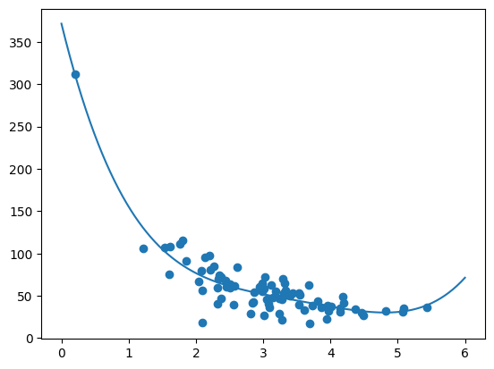

```python
# Creating model
model = np.poly1d(np.polyfit(train_x, train_y, 4))
line = np.linspace(0,6,100)

plt.scatter(train_x, train_y)
plt.plot(line, model(line))
plt.show()
```

### R-Squared

The $r^2$ value tells us how well the data fits the model.

So, we can find the $r^2$ value here.

```python
# R-Squared
r2 = round(r2_score(train_y, model(train_x)), 2)

print(r2)
```

```
0.84
```

This value of $r^2$ is high, so shows a very good fit in the model.

Now, we're convinced that this model is strong, we will use the testing data to test our model.

We will use the R-Squared value to make sure the model fits the training data well too.

```python
print(round(r2_score(test_y, model(test_x)), 2))
```

```
0.55
```

## Decision Tree

A decision tree is a flow chart, and can help you make decisions based on previous experience.

For example, we look at a person who is trying to decide whether they want to go see a comedian or not.

```python
# Importing dataset
import pandas

df = pandas.read_csv("comedian.csv")
print(df)
```

```
    Age  Experience  Rank Nationality   Go
0    36          10     9          UK   NO
1    42          12     4         USA   NO
2    23           4     6           N   NO
3    52           4     4         USA   NO
4    43          21     8         USA  YES
5    44          14     5          UK   NO
6    66           3     7           N  YES
7    35          14     9          UK  YES
8    52          13     7           N  YES
9    35           5     9           N  YES
10   24           3     5         USA   NO
11   18           3     7          UK  YES
12   45           9     9          UK  YES
```

To make a decision tree, all data needs to be in numerical form, so we use a dictionary mapping to convert values into numbers.

```python
# Making Data Numerical
nation = {"UK":0, "USA":1, "N":2}
df["Nationality"] = df["Nationality"].map(nation)
go = {"YES":1, "NO":0}
df["Go"] = df["Go"].map(go)

print(df)
```

```
    Age  Experience  Rank  Nationality  Go
0    36          10     9            0   0
1    42          12     4            1   0
2    23           4     6            2   0
3    52           4     4            1   0
4    43          21     8            1   1
5    44          14     5            0   0
6    66           3     7            2   1
7    35          14     9            0   1
8    52          13     7            2   1
9    35           5     9            2   1
10   24           3     5            1   0
11   18           3     7            0   1
12   45           9     9            0   1
```

Then, we separate the **Feature** columns from the **Target** columns.

The feature columns are columns we try to predict from, and target columns is the column with the values we try to predict.

```python
# Creating Features and Targets
features = ["Age", "Experience", "Rank", "Nationality"]

x = df[features]
y = df["Go"]
```

Now, we can create the actual decision tree, fit it with out details.

```
[Text(0.2857142857142857, 0.9, 'Rank <= 6.5\ngini = 0.497\nsamples = 13\nvalue = [6, 7]'),
```

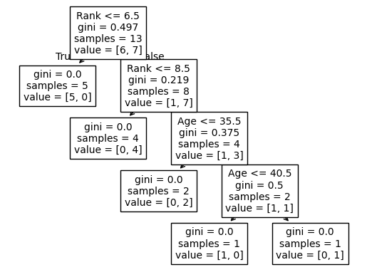

```python
# Creating tree
from sklearn import tree
from sklearn.tree import DecisionTreeClassifier

dtree = DecisionTreeClassifier()
dtree = dtree.fit(x.values,y)

tree.plot_tree(dtree, feature_names=features)
```

### Explaining Results

[feature] $\leq a$ means that every comedian with a feature value of $a$ or lower will follow the true arrow, and the rest will follow the false arrow.

GINI is the method used to split the samples, using the formula: $$ \text{Gini} = 1-\left(\dfrac{x}{n}\right)^2-\left(\dfrac{y}{n}\right)^2 $$ Where x is the number of positive answers ("GO"), n is the number of samples, and y is the number of negative answers ("NO"), which gives us the calculation.

samples refers to the number of participants left at this point in the decision.

value = [a,b] refers to the fact that of the a+b participants left, a will get a "NO", and b will get a "GO".

We can now use the decision tree to predict new values.

```python
# Predicting Values for a 40 year old, American comedian with 10 years of experience and a rank of 7
prediction = dtree.predict([[40,10,7,1]])
print(list(go.keys())[list(go.values()).index(prediction[0])])
```

```
YES
```

## Confusion Matrix

A confusion matrix is a table used in classification problems to assess where errors in the model were made.

The rows represent actual classes the outcomes should've been, while the columns represent the prediction we have made. Using the table lets us see which predictions are wrong.

To create a confusion matrix, we need to generate actual and predicted values by utilising NumPy.

```python
# Generating Actual and Predicted Values
import numpy as np
from sklearn import metrics
import matplotlib.pyplot as plt

actual = np.random.binomial(1, 0.9, size = 1000)
predicted = np.random.binomial(1, 0.9, size=1000)

confusion_matrix = metrics.confusion_matrix(actual, predicted)

print(confusion_matrix)
```

```
[[  7  79]
 [ 87 827]]
```

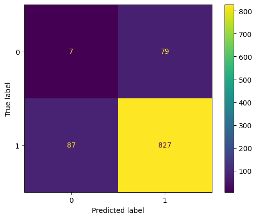

```python
# Visualising Matrix
cm_display = metrics.ConfusionMatrixDisplay(confusion_matrix=confusion_matrix, display_labels=[0,1])

cm_display.plot()
plt.show()
```

A confusion matrix has 4 different quadrants:

- True Negative (Top-Left Quadrant)
- False Positive (Top-Right Quadrant)
- False Negative (Bottom-Left Quadrant)
- True Positive (Bottom-Right Quadrant)

True means the values were accurately predicted, and false means there was an error or wrong prediction.

### Created Metrics

**Accuracy:**

Measures how often the model is correct. $$ \text{Accuracy} = \dfrac{\text{True Positive}+\text{True Negative}}{\text{Total Predictions}} $$

```python
Accuracy = metrics.accuracy_score(actual, predicted)
print(round(Accuracy, 2))
```

```
0.83
```

**Precision:**

Of the positives predicted, what percentage is truly positive. $$ \text{Accuracy} = \dfrac{\text{True Positive}}{\text{True Positive}+\text{False Positive}} $$

```python
Precision = metrics.precision_score(actual, predicted)
print(round(Precision, 2))
```

```
0.91
```

**Sensitivity (Recall):**

Of all the positive cases, what percentage are predicted positive. $$ \text{Sensitivity} = \dfrac{\text{True Positive}}{\text{True Positive}+\text{False Negative}} $$

```python
Sensitivity = metrics.recall_score(actual, predicted)
print(round(Sensitivity, 2))
```

```
0.9
```

**Specificity:**

How well can the model predict negative results. $$ \text{Specificity} = \dfrac{\text{True Negative}}{\text{True Negative}+\text{False Positive}} $$

```python
Specificity = metrics.recall_score(actual, predicted, pos_label = 0)
print(round(Specificity, 2))
```

```
0.08
```

**F-Score:**

F-Score is the "harmonic mean" of precision and sensitivity.

It considers both false positive and false negative cases and is good for imbalanced datasets.

$$ \text{F-Score} = 2\times\dfrac{\text{Precision}\times\text{Sensitivity}}{\text{Precision}+\text{Sensitivity}} $$

```python
F1_Score = metrics.f1_score(actual, predicted)
print(round(F1_Score, 2))
```

```
0.91
```

## Hierarchical Clustering

Hierarchical clustering is an unsupervised learning method for clustering data points. The algorithm builds clusters by measuring the dissimilarities between data.

Unsupervised learning means a model does not need to be trained, and we do not need a "target" variable.

This method can be used on any data to visualise and interpret the relationship between individual data points.

This works by something called Agglomerative Clustering, a type of hierarchical clustering that follows a bottom up approach. We begin by treating each data point as its own cluster, and then we join clusters together that have the shortest distance between them, until we have 1 large cluster containing all the data points.

Hierarchical clustering requires us to decide on both a distance and linkage method. We will use euclidean distance and Ward linkage method, which attempts to minimise the variance between clusters.

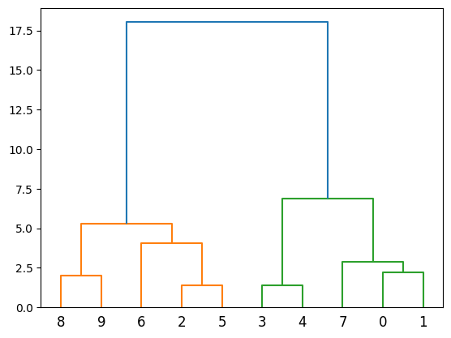

```python
# Making a Cluster Dendogram
import numpy as np
import matplotlib.pyplot as plt
from scipy.cluster.hierarchy import dendrogram, linkage

x = [4, 5, 10, 4, 3, 11, 14 , 6, 10, 12]
y = [21, 19, 24, 17, 16, 25, 24, 22, 21, 21]

data = list(zip(x, y))

linkage_data = linkage(data, method="ward", metric="euclidean")
dendrogram(linkage_data)

plt.show()
```

We can do the same thing with sklearn, and plot it on a scatter.

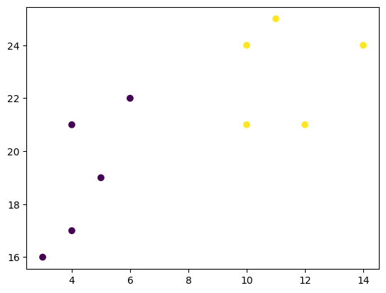

```python
# Making a Cluster Scatter plot
from sklearn.cluster import AgglomerativeClustering

hierarchical_cluster = AgglomerativeClustering(n_clusters=2)
labels = hierarchical_cluster.fit_predict(data)

plt.scatter(x,y,c=labels)
plt.show()
```

## Logistic Regression

Logistic regression aims to solve classification problems. It does this by predicting categorical outcomes, while linear regression predicts a continuous outcome.

In the simplest case, we have only 2 categories/outcomes, i.e. a binomial regression.

Other cases have more than 2 outcomes to classify, in which case it is called multinomial.

Here, we'll use logistic regression to predict a binomial variable - In this case, we are trying to assess the relationship between the size of a tumour and its malignancy.

We want to see whether a tumor of size 3.46 is malignant.

```python
# Getting Data and using NumPy for Analysis
import numpy as np
from sklearn import linear_model

x = np.array([3.78, 2.44, 2.09, 0.14, 1.72, 1.65, 4.92, 4.37, 4.96, 4.52, 3.69, 5.88]).reshape(-1,1)
y = np.array([0, 0, 0, 0, 0, 0, 1, 1, 1, 1, 1, 1])

logr = linear_model.LogisticRegression()
logr.fit(x,y)


s = 3.46
predicted = logr.predict(np.array(s).reshape(-1,1))

print(predicted)
```

```
[0]
```

### Metrics

**Coefficient:**

In log regression, the coefficient tells us the log-odds of having the outcome per unit change in x.

```python
log_odds = logr.coef_
odds = np.exp(log_odds)

print(odds)
```

```
[[4.03557295]]
```

Which tells us that as the size of a tumor increases by 1mm, the odds of it being malignant increases by 4x.

**Probability:**

The coefficient and intercept values can be used to find the probability that each tumor is cancerous.

We find the probability by: $$ odds = e^{ax+c} $$ Where a is the log coefficient and c is the log intercept. $$ p = \dfrac{\text{odds}}{1+\text{odds}} $$

```python
# Probability
def logit2prob(logr, x):
    log_odds = logr.coef_ * x + logr.intercept_
    odds = np.exp(log_odds)
    probability = odds / (1+odds)
    return probability

logit2prob(logr, s)
```

```
array([[0.49758334]])
```

Which gives the probability of a tumor of size 3.46mm is malignant.

## Grid Search

The majority of ML models contain parameters that can be adjusted to vary how the model learns. For example, the log regression model from sklearn, has a parameter c that controls regularisation, which affects the complexity of the model.

One technique is to try out different values then pick the value that does the best score - a technique known as a grid search.

If we had to select more than 1 value, we could use combinations of values, thus forming a grid of values.

```python
# Calculating score on defualt value
from sklearn import datasets
from sklearn.linear_model import LogisticRegression

iris = datasets.load_iris()

x = iris["data"]
y = iris["target"]

logit = LogisticRegression(max_iter = 10000)

logit.fit(x,y)
print(logit.score(x,y))
```

```
0.9733333333333334
```

```python
# Calculating score on Grid Search
C = np.arange(0.25, 2.25, 0.25)

scores = []

for i in C:
    logit.set_params(C=i)
    logit.fit(x,y)
    scores.append(logit.score(x,y))

index = scores.index(max(scores))
print(C[index])
```

```
1.75
```

This shows us that from our set of C values, 1.75 performs the best as providing the highest accuracy in the model.

However, since we scored our logistic regression by using the same data that was used to train it. The model may correspond too closely to the data, so may not perform well in predicting unseen data.

This is known as over-fitting, and must be avoided where possible.

## Categorical Data

When your data has categories represented by strings, it is difficult to use them to train ML models, which often only accepts numeric data.

Instead of ignoring the categorical data, we can transform the data so it can be used in the models.

Earlier, we used a dataset about cars, in which we ignored the brand and model, in order to deal with things numerically.

Now, we want to use this information about brand and model, as it may provide some insights that numerical data alone cannot.

Here, we use something called One Hot Encoding, which is done by having a column that represents each group in the category.

For each column, the values will be 1 or 0, where 1 represents inclusion and 0 represents exclusion.

```python
# Create One Hot Encoding Table
import pandas as pd

cars = pd.read_csv("datavol.csv")
ohe_cars = pd.get_dummies(cars[["Car"]])

print(ohe_cars)
```

```
    Car_Audi  Car_BMW  Car_Fiat  Car_Ford  Car_Honda  Car_Hundai  Car_Hyundai  \
0      False    False     False     False      False       False        False
1      False    False     False     False      False       False        False
2      False    False     False     False      False       False        False
3      False    False      True     False      False       False        False
4      False    False     False     False      False       False        False
5      False    False     False     False      False       False        False
6      False    False     False     False      False       False        False
7      False    False     False     False      False       False        False
8      False    False     False      True      False       False        False
9       True    False     False     False      False       False        False
10     False    False     False     False      False       False         True
11     False    False     False     False      False       False        False
12     False    False     False      True      False       False        False
13     False    False     False     False       True       False        False
```

[output cut: 98 more lines]

We can use this alongside volume and weight to predict $CO_2$.

To combine the information, we use the `concat()` function from pandas.

```python
# One Hot Encoding Prediction
from sklearn import linear_model

x = pandas.concat([cars[["Volume", "Weight"]], ohe_cars], axis = 1)
y = cars["CO2"]

regr = linear_model.LinearRegression()
regr.fit(x.values,y)

# Predicting the CO2 emissions of a Volvo where the weight is 2300kg and the volume is 1300cm^3
predictedCO2 = regr.predict([[2300, 1300, 0,0,0,0,0,0,0,0,0,0,0,0,0,0,0,1,0]])

print(round(predictedCO2[0],1))
```

```
122.5
```

## K-Means

K-means is an unsupervised learning method for clustering data points. The algorithm iteratively divides data points into K clusters by minimizing the variance in each cluster.

First, each data point is randomly assigned to one of the K clusters. Then, we compute the centroid of each cluster and reassign each data point to the cluster with the closest centroid - which is repeated until assignments are no longer changing.

This requires us to pick a K, the number of clusters. The elbow method lets us graph the inertia and visualise the point at which it starts decreasing linearly, which is referred to as the elbow, and is a good estimate for the best value for K, based on the data.

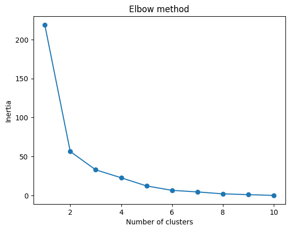

```python
# Getting Data and Finding K
import matplotlib.pyplot as plt
from sklearn.cluster import KMeans

x = [4, 5, 10, 4, 3, 11, 14 , 6, 10, 12]
y = [21, 19, 24, 17, 16, 25, 24, 22, 21, 21]

data = list(zip(x, y))
inertias = []

for i in range(1,11):
    kmeans = KMeans(n_clusters=i)
    kmeans.fit(data)
    inertias.append(kmeans.inertia_)

plt.plot(range(1,11), inertias, marker='o')
plt.title('Elbow method')
plt.xlabel('Number of clusters')
plt.ylabel('Inertia')
plt.show()
```

The elbow method shows us that $K=2$ is a good value for our model.

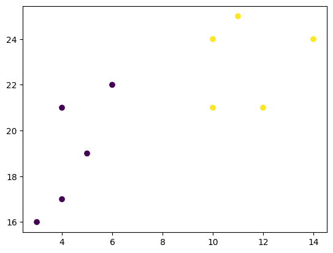

```python
# K-Means at 2 Clusters
kmeans = KMeans(n_clusters=2)
kmeans.fit(data)

plt.scatter(x, y, c=kmeans.labels_)
plt.show()
```

See kmeans.py in this folder for my own implementation of KMeans clustering, with comments.

## Bootstrap Aggregation (Bagging)

Methods like decision trees can be prone to overfitting on the training set, which can lead to wrong predictions on new data.

Bagging is an ensembling method that attempts to resolve overfitting for classification or regression problems. Bagging aims to improve the accuracy and performance of machine learning algorithms.

It does this by taking random subsets of an original dataset with replacement, and fits either a classifier or regressor to each subset.

The predictions for each subset are then aggregated through majority vote for classification or averaging for regression, increasing prediction accuracy.

To see how bagging can improve model performance, we must start by evaluating how the base classifier performs on the dataset.

We will use sklearn's wine dataset to identify different classes of wine.

```python
# Wine Bagging
from sklearn import datasets
from sklearn.model_selection import train_test_split
from sklearn.metrics import accuracy_score
from sklearn.tree import DecisionTreeClassifier

data = datasets.load_wine(as_frame = True)

x = data.data
y = data.target

x_train, x_test, y_train, y_test = train_test_split(x, y, test_size = 0.25)

dtree = DecisionTreeClassifier()
dtree.fit(x_train,y_train)

y_pred = dtree.predict(x_test)

print("Train data accuracy:",accuracy_score(y_true = y_train, y_pred = dtree.predict(x_train)))
print("Test data accuracy:",accuracy_score(y_true = y_test, y_pred = y_pred))
```

```
Train data accuracy: 1.0
Test data accuracy: 0.9555555555555556
```

We see that the base classifier performs reasonably well on the dataset achieving high accuracy on the test dataset with the current parameters.

### Creating a Bagging Classifier

For bagging, we need to set the parameter n_estimators, which is the number of base classifiers that our model is going to aggregate together.

For the sample dataset, the number of estimators is relatively low and it is often the case that much larger ranges are explored.

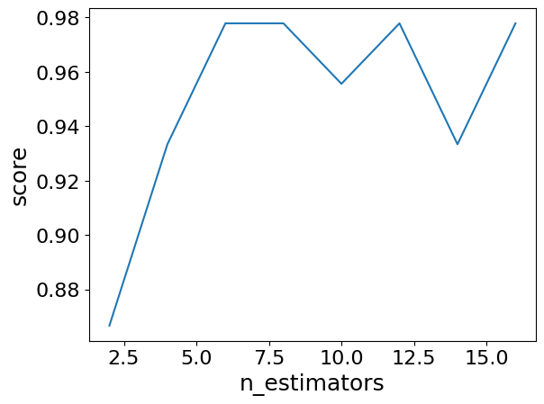

```python
# Creating a Bagging Classifier
from sklearn.ensemble import BaggingClassifier
import matplotlib.pyplot as plt

estimators = [2,4,6,8,10,12,14,16]

models = []
scores = []

for n_estimators in estimators:
    clf = BaggingClassifier(n_estimators=n_estimators)
    clf.fit(x_train, y_train)
    models.append(clf)
    scores.append(accuracy_score(y_true=y_test, y_pred=clf.predict(x_test)))

plt.plot(estimators, scores)

plt.xlabel("n_estimators", fontsize = 18)
plt.ylabel("score", fontsize=18)
plt.tick_params(labelsize = 16)

plt.show()
```

Since we are using random data here, it's best practice to use cross validation.

As bootstrapping chooses random subsets of observations to make classifiers, there are observations that are left out in the selection process.

These "out-of-bag" observations can be used to evaluate the model, similarly to that of a test set. Bearing in mind that out-of-bag estimation can overestimate error in binary classification problems, and should only be used as a compliment to other metrics.

We will use 12 estimators here.

```python
# Out Of Bag Observations
from sklearn import datasets
from sklearn.model_selection import train_test_split
from sklearn.ensemble import BaggingClassifier

data = datasets.load_wine(as_frame= True)

x = data.data
y = data.target

x_train, x_test, y_train, y_test = train_test_split(x, y, test_size = 0.25)

oob_model = BaggingClassifier(n_estimators = 12, oob_score = True)

oob_model.fit(x_train, y_train)

print(oob_model.oob_score_)
```

```
0.9473684210526315
```

### Generating Decision Trees from Bagging Classifier

As was seen in the Decision Tree lesson, it is possible to graph the decision tree the model created. It is also possible to see the individual decision trees that went into the aggregated classifier.

This is only really functional with smaller datasets, where trees are easier to visualise.

```
[Text(0.5909090909090909, 0.875, 'proline <= 875.0\ngini = 0.651\nsamples = 88\nvalue = [42, 57, 34]'),
```

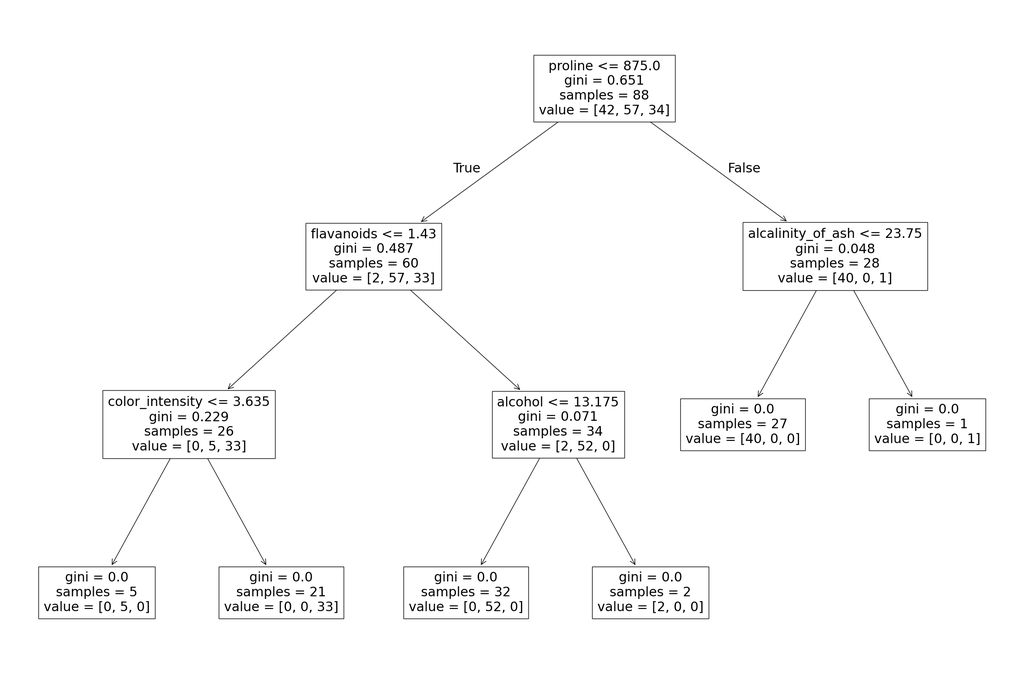

```python
# Generating Decision Trees
from sklearn.tree import plot_tree

clf = BaggingClassifier(n_estimators = 12, oob_score = True)
clf.fit(x_train, y_train)

plt.figure(figsize=(30, 20))
plot_tree(clf.estimators_[0], feature_names = x.columns)
```

## Cross Validation

When adjusting models we are aiming to increase overall model performance on unseen data. Hyperparameter tuning can lead to better performance on test sets. However, optimizing parameters can lead to information leakage, causing the model to preform worse on unseen data.

To correct for this we can perform cross validation.

To understand this, we will be performing different methods on the iris dataset.

```python
# Cross Validation
from sklearn import datasets

x,y = datasets.load_iris(return_X_y=True)
```

### K-Fold

The training data used in the model is split into k number of smaller sets, to be used to validate the model. The model is then trained on $k-1$ folds of the training set. The remaining fold is then used to evaluate the model.

As we will be trying to classify different species of iris flowers we will need to import a classifier model, for this exercise we will be using a `DecisionTreeClassifier`. We will also need to import CV modules from `sklearn`.

```python
#K-Fold Validation
from sklearn.tree import DecisionTreeClassifier
from sklearn.model_selection import KFold, cross_val_score

clf = DecisionTreeClassifier()
kfolds = KFold(n_splits = 5)

scores = cross_val_score(clf, x, y, cv = kfolds)

print(f"CV Scores : {scores} \nAverage CV Scores : {np.mean(scores)}")
```

```
CV Scores : [1.         1.         0.9        0.93333333 0.76666667]
Average CV Scores : 0.9199999999999999
```

### Stratified K-Fold

In cases where classes are imbalanced, we need a way to account for the imbalance in both the train and validation sets.

To do so, we stratify the target classes, meaning that both sets will have an equal proportion of all classes.

```python
# Stratified K-Fold Validation
from sklearn.model_selection import StratifiedKFold

skfolds = StratifiedKFold(n_splits = 5)

scores = cross_val_score(clf, x, y, cv=skfolds)

print(f"CV Scores : {scores} \nAverage CV Scores : {np.mean(scores)}")
```

```
CV Scores : [0.96666667 0.96666667 0.9        1.         1.        ]
Average CV Scores : 0.9666666666666668
```

### Leave-One-Out (LOO)

Instead of selecting the number of splits in the training data set like k-fold does, Leave-One-Out utilises 1 observation to validate and n-1 observations to train. This method is an exhaustive technique.

```python
# LOO Validation
from sklearn.model_selection import LeaveOneOut

loo = LeaveOneOut()

scores = cross_val_score(clf, x, y, cv=loo)

print(f"CV Scores : {scores} \nAverage CV Scores : {np.mean(scores)}")
```

```
CV Scores : [1. 1. 1. 1. 1. 1. 1. 1. 1. 1. 1. 1. 1. 1. 1. 1. 1. 1. 1. 1. 1. 1. 1. 1.
 1. 1. 1. 1. 1. 1. 1. 1. 1. 1. 1. 1. 1. 1. 1. 1. 1. 1. 1. 1. 1. 1. 1. 1.
 1. 1. 1. 1. 1. 1. 1. 1. 1. 1. 1. 1. 1. 1. 1. 1. 1. 1. 1. 1. 1. 1. 0. 1.
 1. 1. 1. 1. 1. 0. 1. 1. 1. 1. 1. 0. 1. 1. 1. 1. 1. 1. 1. 1. 1. 1. 1. 1.
 1. 1. 1. 1. 1. 1. 1. 1. 1. 1. 0. 1. 1. 1. 1. 1. 1. 1. 1. 1. 1. 1. 1. 0.
 1. 1. 1. 1. 1. 1. 1. 1. 1. 0. 1. 1. 1. 0. 1. 1. 1. 1. 0. 1. 1. 1. 1. 1.
 1. 1. 1. 1. 1. 1.]
Average CV Scores : 0.9466666666666667
```

We can observe that the number of cross validation scores performed is equal to the number of observations in the dataset. In this case there are 150 observations in the iris dataset.

### Leave-P-Out (LPO)

Leave-P-Out is simply a nuanced diffence to the Leave-One-Out idea, in that we can select the number of p to use in our validation set.

```python
# LPO Validation
from sklearn.model_selection import LeavePOut

lpo = LeavePOut(p=2)

scores = cross_val_score(clf, x, y, cv=lpo)

print(f"CV Scores : {scores} \nAverage CV Scores : {np.mean(scores)}")
```

```
CV Scores : [1. 1. 1. ... 1. 1. 1.]
Average CV Scores : 0.9485906040268456
```

### Shuffle Split

Unlike K-Fold, Shuffle Split leaves out a percentage of the data, not to be used in the train or validation sets.

To do so, we must decide what the train and test sizes are, as well as the number of splits.

```python
# Shuffle Split Validation
from sklearn.model_selection import ShuffleSplit

ss = ShuffleSplit(train_size=0.6, test_size=0.3, n_splits=5)

scores = cross_val_score(clf, x, y, cv = ss)

print(f"CV Scores : {scores} \nAverage CV Scores : {np.mean(scores)}")
```

```
CV Scores : [0.97777778 0.95555556 0.91111111 0.97777778 0.91111111]
Average CV Scores : 0.9466666666666667
```

## AUC-ROC Curve

In classification, there are many different evaluation metrics. The most popular is accuracy, which measures how often the model is correct

Another common metric is AUC, area under the receiver operating characteristic (ROC) curve. The Reciever operating characteristic curve plots the true positive (TP) rate versus the false positive (FP) rate at different classification thresholds.

Suppose we have an imbalanced data set, where the majority of the data is of one value. We could just predict that the model is always of that value, but then we have some issues.

```python
# Examples of AUC-ROC Curve
import numpy as np
from sklearn.metrics import accuracy_score, confusion_matrix, roc_auc_score, roc_curve

n = 10000
ratio = 0.95
n0 = int((1-ratio)*n)
n1 = int(ratio*n)

y = np.array([0]*n0 + [1]*n1)

y_proba = np.array([1]*n)
y_pred = y_proba > 0.5

print(f"Accuracy Score = {accuracy_score(y, y_pred)}")
cfmat = confusion_matrix(y, y_pred)
print(cfmat)
print(f"Class 0 Accuracy = {cfmat[0][0]/n0}")
print(f"Class 1 Accuracy = {cfmat[1][1]/n1}")
```

```
Accuracy Score = 0.95
[[   0  500]
 [   0 9500]]
Class 0 Accuracy = 0.0
Class 1 Accuracy = 1.0
```

Now, we accurately predict class 1 100% of the time, but the model accurately predicts class 0 0% of the time.

So, rather than just picking class 1 for everything, we might be better off choosing a different model.

```python
yproba2 = np.array(np.random.uniform(0, 0.7, n0).tolist() + np.random.uniform(0.3, 1, n1).tolist())
ypred2 = yproba2 > 0.5

print(f"Accuracy Score = {accuracy_score(y, ypred2)}")
cfmat = confusion_matrix(y, ypred2)
print(cfmat)
print(f"Class 0 Accuracy = {cfmat[0][0]/n0}")
print(f"Class 1 Accuracy = {cfmat[1][1]/n1}")
```

```
Accuracy Score = 0.7131
[[ 357  143]
 [2726 6774]]
Class 0 Accuracy = 0.714
Class 1 Accuracy = 0.7130526315789474
```

Here, the accuracy score is lower, but the accuracy for each class is more balanced, so accuracy is not useful as a metric, so we prefer to use another evaluation metric, like AUC.

```
Model 1 AUC Score : 0.5
```

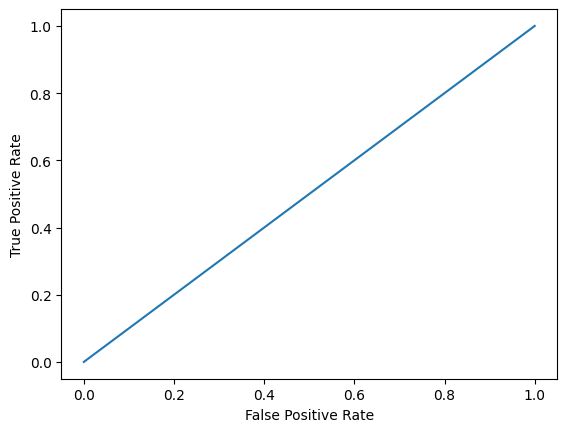

```
Model 2 AUC Score : 0.8360212631578947
```

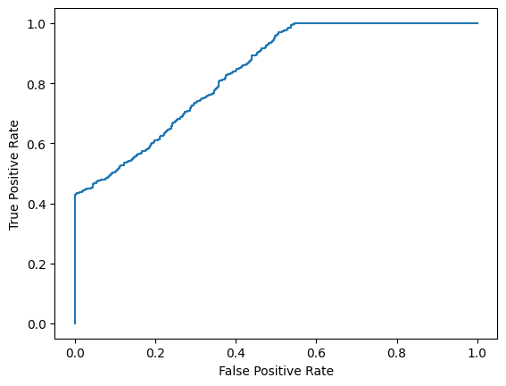

```python
# AUC Implementation
import matplotlib.pyplot as plt

def plot_roc_curve(truey, yprob):
    falsep, truep, t = roc_curve(truey, yprob)
    plt.plot(falsep, truep)
    plt.xlabel("False Positive Rate")
    plt.ylabel("True Positive Rate")
    plt.show()

print(f"Model 1 AUC Score : {roc_auc_score(y, y_proba)}")
plot_roc_curve(y, y_proba)

print(f"Model 2 AUC Score : {roc_auc_score(y, yproba2)}")
plot_roc_curve(y, yproba2)
```

An AUC score of 0.5 means that the model is unable to make a distinction between 2 classes, and the curve looks like a line with slope 1.

An AUC scorre closer to 1 means the model is better as distinguishing between classes, and the curve tends towards the top left corner.

An AUC score of 1 indicates the model is perfect, but this is not always the best thing we want, as it can often be the result of overfitting.

### Probabilities

Because AUC is a metric that utilises probabilities of the class predictions, we can be more confident in a model that has a higher AUC score, than one with a lower score even if they have similar accuracies.

Below, we have 2 data sets, one unconfident model which has probabilities close of 0.5, and one more confident model, which has more extreme probabilities (close to 1 or 0).

```
Model 1 Accuracy Score: 0.75135
Model 1 AUC Score : 0.7729708100000001
```

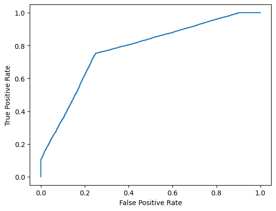

```
Model 2 Accuracy Score: 0.75095
Model 2 AUC Score : 0.8600317199999998
```

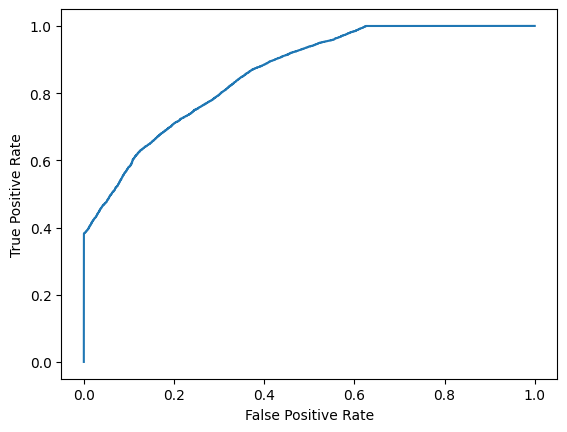

```python
# Model Comparison
n = 10000
y = np.array([0]*n + [1]*n)

y_prob1 = np.array(
    np.random.uniform(0.25, 0.5, n//2).tolist() +
    np.random.uniform(0.3, 0.7, n).tolist() +
    np.random.uniform(0.5, 0.75, n//2).tolist()
)

y_prob2 = np.array(
    np.random.uniform(0, 0.4, n//2).tolist() +
    np.random.uniform(0.3, 0.7, n).tolist() +
    np.random.uniform(0.6, 1, n//2).tolist()
)

# Important! roc_auc_score takes input as actual results, not results
print(f'Model 1 Accuracy Score: {accuracy_score(y, y_prob1 > 0.5)}')
print(f"Model 1 AUC Score : {roc_auc_score(y, y_prob1)}")
plot_roc_curve(y, y_prob1)

print(f'Model 2 Accuracy Score: {accuracy_score(y, y_prob2 > 0.5)}')
print(f"Model 2 AUC Score : {roc_auc_score(y, y_prob2)}")
plot_roc_curve(y, y_prob2)
```

So, even though the accuracies are similar, the model with the higher AUC score will be more reliable because it takes into account the predicted probability.

Thus, when predicting future probability, it is more likely to be more accurate.

## K Nearest Neighbours (KNN)

KNN is a simple, supervised ML algorithm that can be used for classification or regression tasks - also used in missing value imputation (a process that replaces missing values with estimated ones).

It is based on the idea that observations closest to a given data point are the most similar observations in a dataset.

Thus, we can classify unforeseen points by the points around it, and by choosing K, the user can select the number of nearby observations to use in the algorithm.

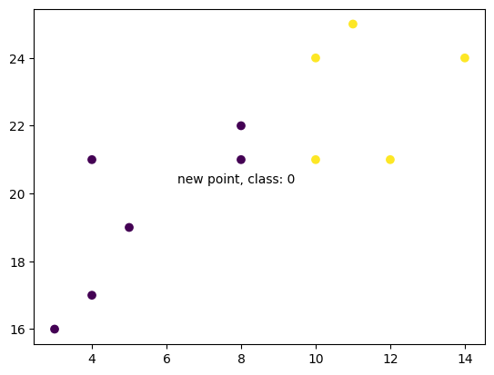

```python
# Simple KNN to predict the class of a new point, with k=1
from sklearn.neighbors import KNeighborsClassifier

x = [4, 5, 10, 4, 3, 11, 14 , 8, 10, 12]
y = [21, 19, 24, 17, 16, 25, 24, 22, 21, 21]
classes = [0, 0, 1, 0, 0, 1, 1, 0, 1, 1]

data = list(zip(x,y))
knn = KNeighborsClassifier(n_neighbors=1)

knn.fit(data, classes)

new_x = 8
new_y = 21
new_point = [(new_x, new_y)]

prediction = knn.predict(new_point)

plt.scatter(x+[new_x], y+[new_y], c=classes+[prediction[0]])
plt.text(x = new_x-1.7, y= new_y - 0.7, s = f"new point, class: {prediction[0]}")
plt.show()
```

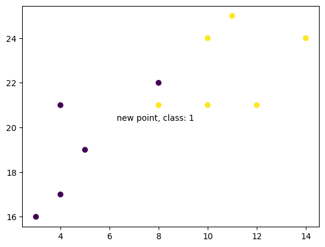

```python
# Same KNN with k=5
knn = KNeighborsClassifier(n_neighbors=5)

knn.fit(data, classes)

new_x = 8
new_y = 21
new_point = [(new_x, new_y)]

prediction = knn.predict(new_point)

plt.scatter(x+[new_x], y+[new_y], c=classes+[prediction[0]])
plt.text(x = new_x-1.7, y= new_y - 0.7, s = f"new point, class: {prediction[0]}")
plt.show()
```